# Lab week 4 - Unsupervised methods

Data Science and Machine Learning 1 - CEU 2018

Jeno Pal

2018-01-30

```r
library(data.table)
library(caret)
library(skimr)
library(datasets)
library(ggplot2)
library(ISLR)
library(NbClust)
library(factoextra)
theme_set(theme_minimal())
```

## Principal Component Analysis (PCA)

We transform the coordinates of the original variables to capture as much variation as we can with independent (orthogonal) dimensions.

```r
data <- USArrests
# data <- data.table(data, keep.rownames = TRUE)
# setnames(data, "rn", "state")
print(skim(data))
```

```
Skim summary statistics
 n obs: 50
 n variables: 4
```

```
Variable type: integer
 variable missing complete  n   mean    sd p0   p25 median    p75 p100     hist
  Assault       0       50 50 170.76 83.34 45 109      159 249     337 ▇▇▅▇▂▇▅▂
 UrbanPop       0       50 50  65.54 14.47 32  54.5     66  77.75   91 ▂▃▆▅▇▆▇▃

Variable type: numeric
 variable missing complete  n  mean   sd  p0   p25 median   p75 p100     hist
   Murder       0       50 50  7.79 4.36 0.8  4.08   7.25 11.25 17.4 ▇▇▇▇▃▇▁▃
     Rape       0       50 50 21.23 9.37 7.3 15.08  20.1  26.17 46   ▆▇▇▆▃▂▂▂
```

Scaling: necessary to have comparable units of different variables. (Multiplying a variable by 100 increases the variance and PCA would try to capture that, even though it is only an artifact of units. We don’t want that.)

```r
pca_result <- prcomp(data, scale. = TRUE)
print(pca_result)
```

```
Standard deviations (1, .., p=4):
[1] 1.5748783 0.9948694 0.5971291 0.4164494

Rotation (n x k) = (4 x 4):
                PC1        PC2        PC3         PC4
Murder   -0.5358995  0.4181809 -0.3412327  0.64922780
Assault  -0.5831836  0.1879856 -0.2681484 -0.74340748
UrbanPop -0.2781909 -0.8728062 -0.3780158  0.13387773
Rape     -0.5434321 -0.1673186  0.8177779  0.08902432
```

```r
names(pca_result)
```

```
[1] "sdev"     "rotation" "center"   "scale"    "x"
```

```r
# weights sum to one
colSums(pca_result$rotation^2)
```

```
PC1 PC2 PC3 PC4
  1   1   1   1
```

```r
# PCA components are orthogonal
sum(pca_result$rotation[, 1] * pca_result$rotation[, 2])
```

```
[1] -1.387779e-16
```

We can plot observations as well as original features in the space spanned by the first two principal components.

```
Ignoring unknown parameters: scale
```

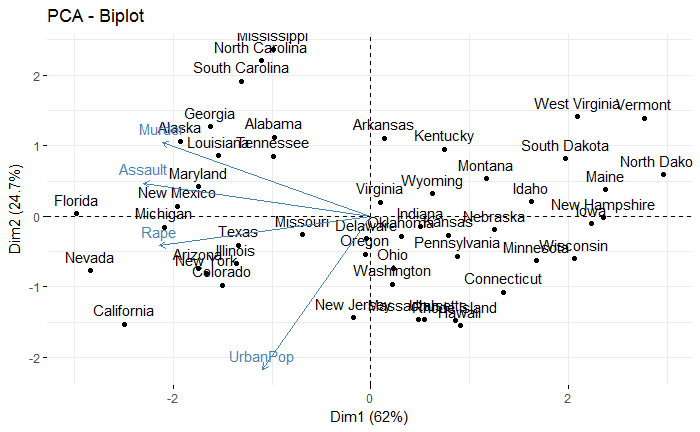

```r
fviz_pca(pca_result, scale = 0)
```

We can plot how much of total variance is captured by subsequent principal components (and in total). Total variance: if scaling was done, it equals the number of variables (since it is 1 for each variable).

```r
variances
```

```
[1] 2.4802416 0.9897652 0.3565632 0.1734301
```

```r
share_variance_by_component <- variances / total_variance
dt_variance <- data.table(component = 1:length(variances),
                          share_variance = share_variance_by_component)
dt_variance[, cum_share_variance := cumsum(share_variance)]
```

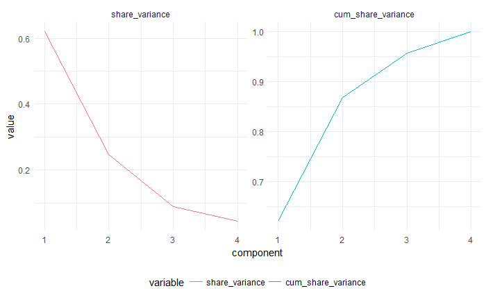

```r
ggplot(data = melt(dt_variance, id.vars = "component")) +
  geom_line(aes(x = component, y = value, color = variable)) +
  facet_wrap(~ variable, scales = "free_y") +
  theme(legend.position = "bottom")
```

How many components summarize the data? No definite answer: decide based on sufficient variance explained.

### PCA with `caret`

We can use `preProcess` from `caret` to perform the same transformations. These can serve as inputs to `train`.

```r
pre_process <- preProcess(data, method = c("center", "scale", "pca"))
pre_process
```

```
Created from 50 samples and 4 variables

Pre-processing:
  - centered (4)
  - ignored (0)
  - principal component signal extraction (4)
  - scaled (4)

PCA needed 3 components to capture 95 percent of the variance
```

```r
pre_process$rotation
```

```
                PC1        PC2        PC3
Murder   -0.5358995  0.4181809 -0.3412327
Assault  -0.5831836  0.1879856 -0.2681484
UrbanPop -0.2781909 -0.8728062 -0.3780158
Rape     -0.5434321 -0.1673186  0.8177779
```

```r
pre_process <- preProcess(data, method = c("center", "scale", "pca"), pcaComp = 4) # with pcaComp i can set how many PCs I want to preserve
pre_process$rotation
```

```
                PC1        PC2        PC3         PC4
Murder   -0.5358995  0.4181809 -0.3412327  0.64922780
Assault  -0.5831836  0.1879856 -0.2681484 -0.74340748
UrbanPop -0.2781909 -0.8728062 -0.3780158  0.13387773
Rape     -0.5434321 -0.1673186  0.8177779  0.08902432
```

```r
preProcess(data, method = c("center", "scale", "pca"), thresh = 0.999) # i can set the tershold, to what extent I want to capture variance
```

```
Created from 50 samples and 4 variables

Pre-processing:
  - centered (4)
  - ignored (0)
  - principal component signal extraction (4)
  - scaled (4)

PCA needed 4 components to capture 99.9 percent of the variance
```

### Using PCA as an input to supervised learning

Let’s predict baseball player salaries using PCA.

```r
data <- ISLR::Hitters
data <- data.table(data)
print(skim(data))
```

```
Skim summary statistics
 n obs: 322
 n variables: 20

Variable type: factor
  variable missing complete   n n_unique            top_counts ordered
  Division       0      322 322        2 W: 165, E: 157, NA: 0   FALSE
    League       0      322 322        2 A: 175, N: 147, NA: 0   FALSE
 NewLeague       0      322 322        2 A: 176, N: 146, NA: 0   FALSE

Variable type: integer
 variable missing complete   n    mean      sd p0    p25 median     p75  p100     hist
  Assists       0      322 322  106.91  136.85  0   7      39.5  166      492 ▇▂▁▁▁▁▁▁
    AtBat       0      322 322  380.93  153.4  16 255.25  379.5  512      687 ▁▂▇▇▆▆▇▂
   CAtBat       0      322 322 2648.68 2324.21 19 816.75 1928   3924.25 14053 ▇▃▂▂▁▁▁▁
    CHits       0      322 322  717.57  654.47  4 209     508   1059.25  4256 ▇▃▂▂▁▁▁▁
   CHmRun       0      322 322   69.49   86.27  0  14      37.5   90      548 ▇▂▁▁▁▁▁▁
     CRBI       0      322 322  330.12  333.22  0  88.75  220.5  426.25  1659 ▇▃▂▁▁▁▁▁
    CRuns       0      322 322  358.8   334.11  1 100.25  247    526.25  2165 ▇▃▂▂▁▁▁▁
   CWalks       0      322 322  260.24  267.06  0  67.25  170.5  339.25  1566 ▇▃▁▁▁▁▁▁
   Errors       0      322 322    8.04    6.37  0   3       6     11       32 ▇▆▃▂▂▁▁▁
     Hits       0      322 322  101.02   46.45  1  64      96    137      238 ▁▇▇▇▇▅▁▁
    HmRun       0      322 322   10.77    8.71  0   4       8     16       40 ▇▆▃▃▂▁▁▁
  PutOuts       0      322 322  288.94  280.7   0 109.25  212    325     1378 ▇▇▂▁▁▁▁▁
      RBI       0      322 322   48.03   26.17  0  28      44     64.75   121 ▂▇▇▆▃▃▂▁
     Runs       0      322 322   50.91   26.02  0  30.25   48     69      130 ▂▇▇▆▅▃▁▁
    Walks       0      322 322   38.74   21.64  0  22      35     53      105 ▂▇▇▅▅▂▁▁
    Years       0      322 322    7.44    4.93  1   4       6     11       24 ▆▇▅▃▃▂▁▁

Variable type: numeric
 variable missing complete   n   mean     sd   p0 p25 median p75 p100     hist
   Salary      59      263 322 535.93 451.12 67.5 190    425 750 2460 ▇▃▃▁▁▁▁▁
```

```r
data <- data[!is.na(Salary)]
```

Train a simple linear model:

```r
set.seed(857)
lm_fit <- train(Salary ~ . ,
                data = data,
                method = "lm",
                trControl = trainControl(method = "cv", number = 10),
                preProcess = c("center", "scale")
                )
lm_fit
```

```
Linear Regression

263 samples
 19 predictor

Pre-processing: centered (19), scaled (19)
Resampling: Cross-Validated (10 fold)
Summary of sample sizes: 237, 236, 237, 238, 235, 236, ...
Resampling results:

  RMSE      Rsquared   MAE
  331.6176  0.4745606  234.4547

Tuning parameter 'intercept' was held constant at a value of TRUE
```

We can use PCA with specified number of components (or we can also set the `thresh` argument to set a threshold that PCA components explain at least a certain share of the variance):

```r
set.seed(857)
lm_fit_pca <- train(Salary ~ . ,
                    data = data,
                    method = "lm",
                    trControl = trainControl(
                      method = "cv",
                      number = 10,
                      preProcOptions = list(pcaComp = 18)),
                    preProcess = c("center", "scale", "pca")
)
lm_fit_pca
```

```
Linear Regression

263 samples
 19 predictor

Pre-processing: centered (19), scaled (19), principal component signal extraction (19)
Resampling: Cross-Validated (10 fold)
Summary of sample sizes: 237, 236, 237, 238, 235, 236, ...
Resampling results:

  RMSE      Rsquared   MAE
  327.3594  0.4815914  231.6309

Tuning parameter 'intercept' was held constant at a value of TRUE
```

Method `pcr` implements precisely this: linear regression with principal components as explanatory variables. Its hyperparameter is the number of components to be used.

```r
tune_grid <- data.frame(ncomp = 1:19)
set.seed(857)
pcr_fit <- train(Salary ~ . ,
                data = data,
                method = "pcr",
                trControl = trainControl(method = "cv", number = 10),
                tuneGrid = tune_grid,
                preProcess = c("center", "scale")
                )
```

```
1 package is needed for this model and is not installed. (pls). Would you like to try to install it now?
1: yes
2: no
```

## K-means clustering

Goal: group observations that are more similar to each other than to others.

```r
data <- data.table(iris)
setnames(data, c("sepal_length",
                 "sepal_width",
                 "petal_length",
                 "petal_width",
                 "species"))
print(skim(data)) # it is an iterative algo, it converges to one final solution, which depends on the starting points
```

```
Skim summary statistics
 n obs: 150
 n variables: 5

Variable type: factor
 variable missing complete   n n_unique                       top_counts ordered
  species       0      150 150        3 set: 50, ver: 50, vir: 50, NA: 0   FALSE

Variable type: numeric
     variable missing complete   n mean   sd  p0 p25 median p75 p100     hist
 petal_length       0      150 150 3.76 1.77 1   1.6   4.35 5.1  6.9 ▇▁▁▂▅▅▃▁
  petal_width       0      150 150 1.2  0.76 0.1 0.3   1.3  1.8  2.5 ▇▁▁▅▃▃▂▂
 sepal_length       0      150 150 5.84 0.83 4.3 5.1   5.8  6.4  7.9 ▂▇▅▇▆▅▂▂
  sepal_width       0      150 150 3.06 0.44 2   2.8   3    3.3  4.4 ▁▂▅▇▃▂▁▁
```

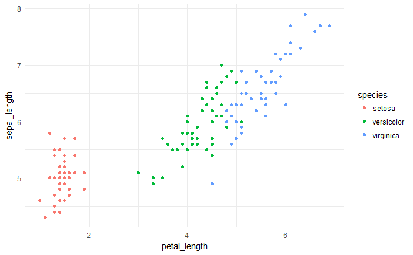

```r
ggplot(data, aes(x = petal_length, y = sepal_length, color = species)) + geom_point()
```

Suppose we do not know labels but want to group observations based on features.

```r
data_features <- data[, .(petal_length, petal_width, sepal_length, sepal_width)]
km <- kmeans(data_features, centers = 3)
km
```

```
K-means clustering with 3 clusters of sizes 38, 62, 50

Cluster means:
  petal_length petal_width sepal_length sepal_width
1     5.742105    2.071053     6.850000    3.073684
2     4.393548    1.433871     5.901613    2.748387
3     1.462000    0.246000     5.006000    3.428000

Clustering vector:
  [1] 3 3 3 3 3 3 3 3 3 3 3 3 3 3 3 3 3 3 3 3 3 3 3 3 3 3 3 3 3 3 3 3 3 3 3 3 3 3 3 3 3 3 3 3 3 3 3 3 3 3 2 2 1 2 2 2 2 2 2 2 2 2 2 2 2 2 2 2 2 2 2 2 2 2 2 2 2 1 2
 [80] 2 2 2 2 2 2 2 2 2 2 2 2 2 2 2 2 2 2 2 2 2 1 2 1 1 1 1 2 1 1 1 1 1 1 2 2 1 1 1 1 2 1 2 1 2 1 1 2 2 1 1 1 1 1 2 1 1 1 1 2 1 1 1 2 1 1 1 2 1 1 2

Within cluster sum of squares by cluster:
[1] 23.87947 39.82097 15.15100
 (between_SS / total_SS =  88.4 %)

Available components:

[1] "cluster"      "centers"      "totss"        "withinss"     "tot.withinss" "betweenss"    "size"         "iter"         "ifault"
```

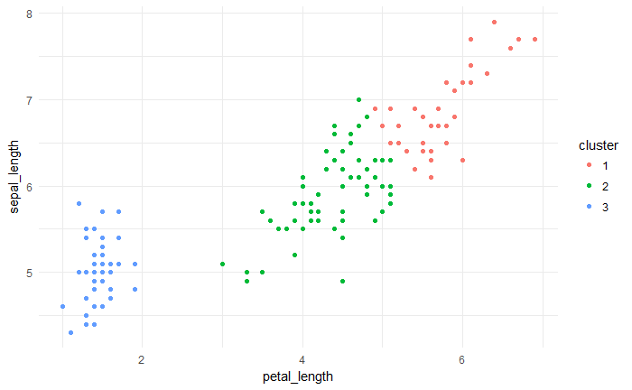

```r
data_w_clusters <- cbind(data_features,
                         data.table("cluster" = factor(km$cluster)))
ggplot(data_w_clusters,
       aes(x = petal_length, y = sepal_length, color = cluster)) +
  geom_point()
```

We can inspect the resulting centers.

```r
km$centers
```

```
  petal_length petal_width sepal_length sepal_width
1     5.742105    2.071053     6.850000    3.073684
2     4.393548    1.433871     5.901613    2.748387
3     1.462000    0.246000     5.006000    3.428000
```

```r
centers <- data.table(km$centers)
str(centers)
```

```
Classes ‘data.table’ and 'data.frame':  3 obs. of  4 variables:
 $ petal_length: num  5.74 4.39 1.46
 $ petal_width : num  2.071 1.434 0.246
 $ sepal_length: num  6.85 5.9 5.01
 $ sepal_width : num  3.07 2.75 3.43
 - attr(*, ".internal.selfref")=<externalptr>
```

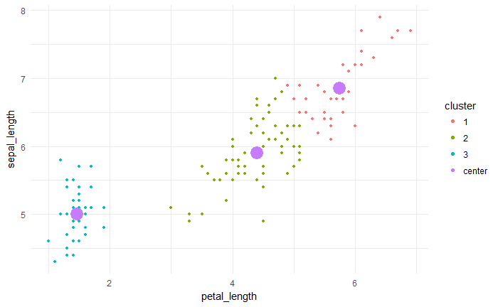

```r
centers[, cluster := factor("center", levels = c(1, 2, 3, "center"))]
data_w_clusters_centers <- rbind(data_w_clusters, centers)
ggplot(data_w_clusters_centers,
       aes(x = petal_length,
           y = sepal_length,
           color = cluster,
           size = ifelse(cluster == "center", 2, 1))) +
  geom_point() +
  scale_size(guide = 'none')
```

Results depend on the starting centers which are randomly chosen observations.

```r
set.seed(1122)
km <- kmeans(data_features, centers = 3, nstart = 1) # nstart - random selection of initial points is done n times. It shouldn't be one, but 20 for example
print(km$centers)
```

```
  petal_length petal_width sepal_length sepal_width
1     1.472727   0.2727273     5.175758    3.624242
2     1.790476   0.3523810     4.738095    2.904762
3     4.973958   1.7031250     6.314583    2.895833
```

```r
print(table(km$cluster))
```

```
 1  2  3
33 21 96
```

```r
print(km$withinss)
```

```
[1]   6.432121  17.669524 118.651875
```

```r
set.seed(123)
km <- kmeans(data_features, centers = 3, nstart = 1)
print(km$centers)
```

```
  petal_length petal_width sepal_length sepal_width
1     1.462000    0.246000     5.006000    3.428000
2     5.742105    2.071053     6.850000    3.073684
3     4.393548    1.433871     5.901613    2.748387
```

```r
print(table(km$cluster))
```

```
 1  2  3
50 38 62
```

```r
print(km$withinss)
```

```
[1] 15.15100 23.87947 39.82097
```

We should always experiment with different starting values (probably generated randomly). `nstart` controls how many times the algorithm is run with different random starting ponits for the centers. Setting it to a high value (e.g., 20) is a good idea to achieve the best groupings.

### Choosing K

There are no general rules, depends on the application. There are some rules of thumb, though. There are many, you can explore some with explanation, [here](http://www.sthda.com/english/wiki/print.php?id=239). `NbClust` calculates 30 indices based on various principles and chooses by majority rule.

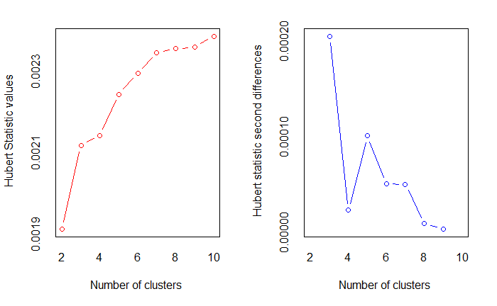

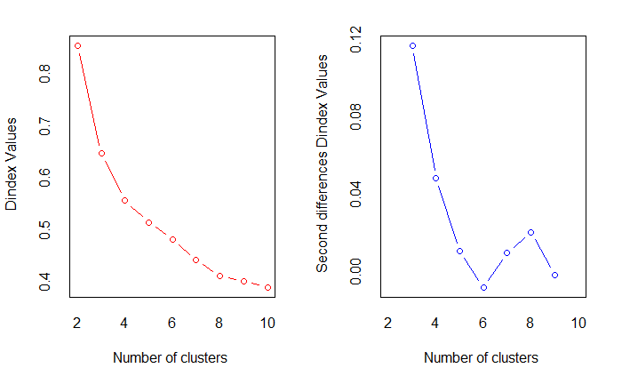

```r
nb <- NbClust(data_features, method = "kmeans",
              min.nc = 2, max.nc = 10, index = "all")
```

```
Among all indices:
===================
* 2 proposed  0 as the best number of clusters
* 10 proposed  2 as the best number of clusters
* 8 proposed  3 as the best number of clusters
* 2 proposed  4 as the best number of clusters
* 1 proposed  5 as the best number of clusters
* 1 proposed  7 as the best number of clusters
* 1 proposed  8 as the best number of clusters
* 1 proposed  10 as the best number of clusters

Conclusion
=========================
* According to the majority rule, the best number of clusters is  2 .
```

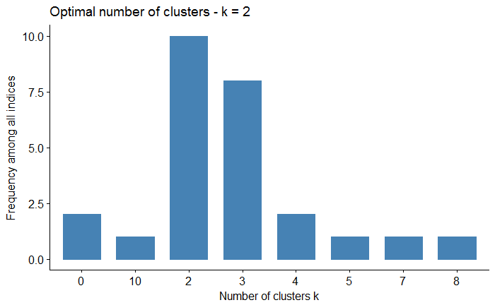

```r
fviz_nbclust(nb)
```

```r
# the gap method illustrated in the lecture
nb <- NbClust(data_features, method = "kmeans",
              min.nc = 2, max.nc = 10, index = "gap")
```

## Hierarchical clustering

With hierarchical clustering we get a nested structure of clusters based on a dissimilarity measure. Is it better than k-means? It depends - k-means does not yield a hierarchical structure. If the data does not have one in reality, hierarchical may be not as good as k-means and there are reversed situations as well.

```r
data_distances <- dist(data_features)
# use the average distance between groups to decide which
# groups to merge next
hc <- hclust(data_distances, method = "average")
```

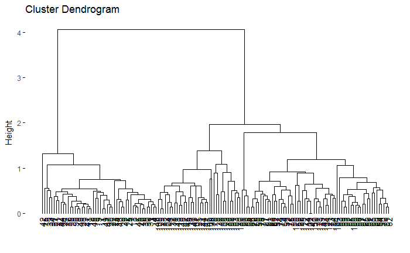

```r
fviz_dend(hc)
```

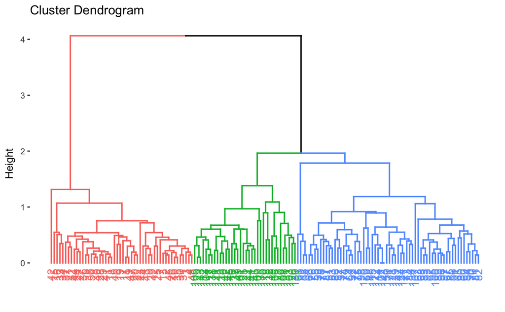

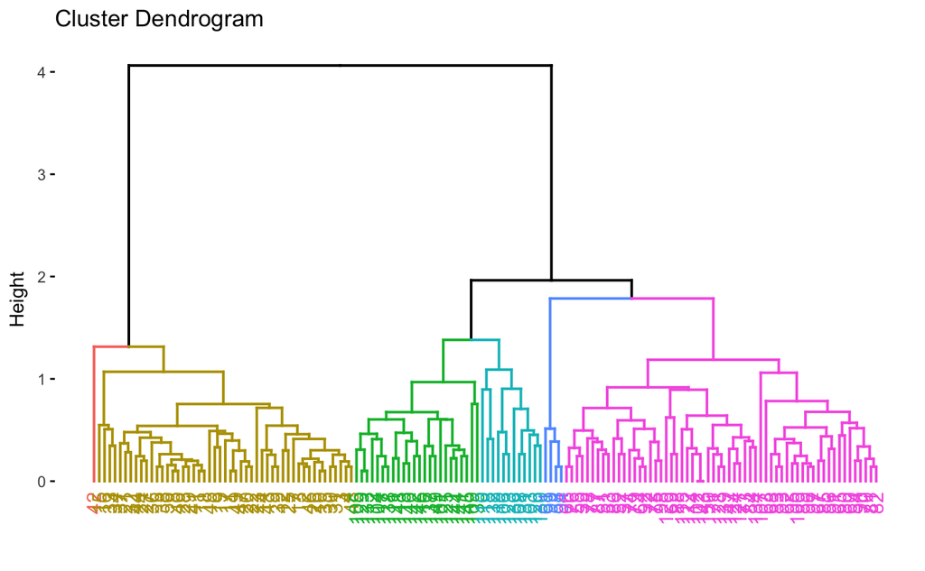

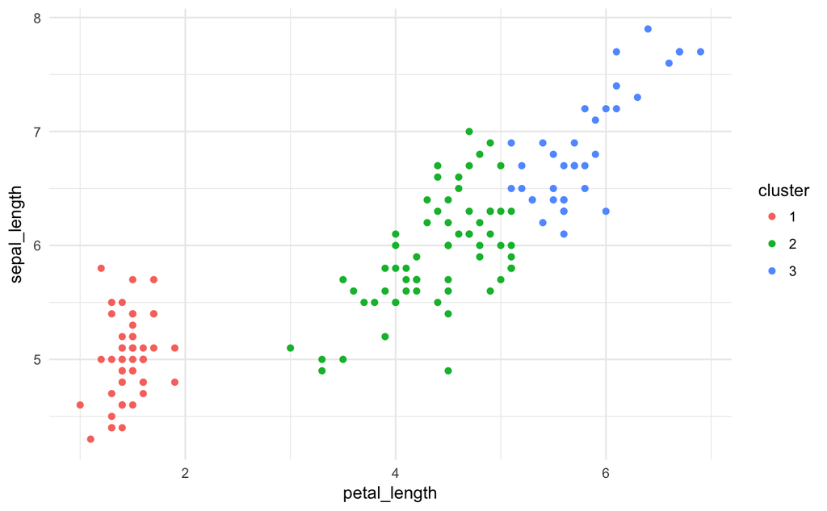

How we calculate similarities between groups may strongly affect the clustering.

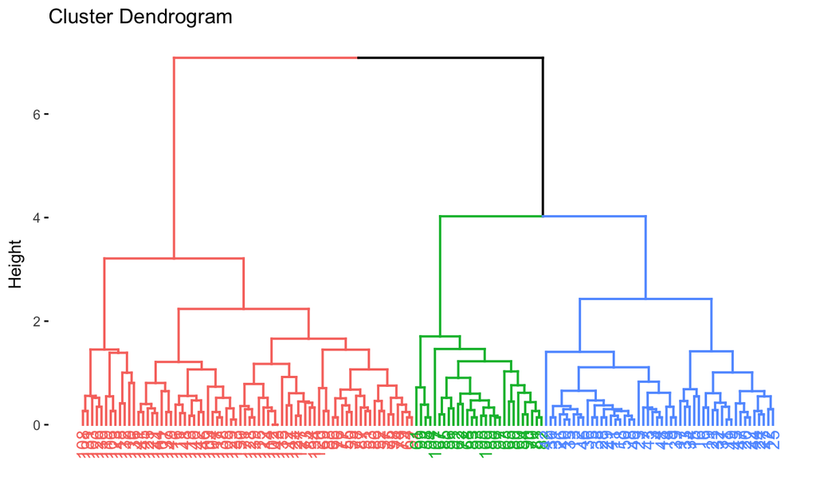

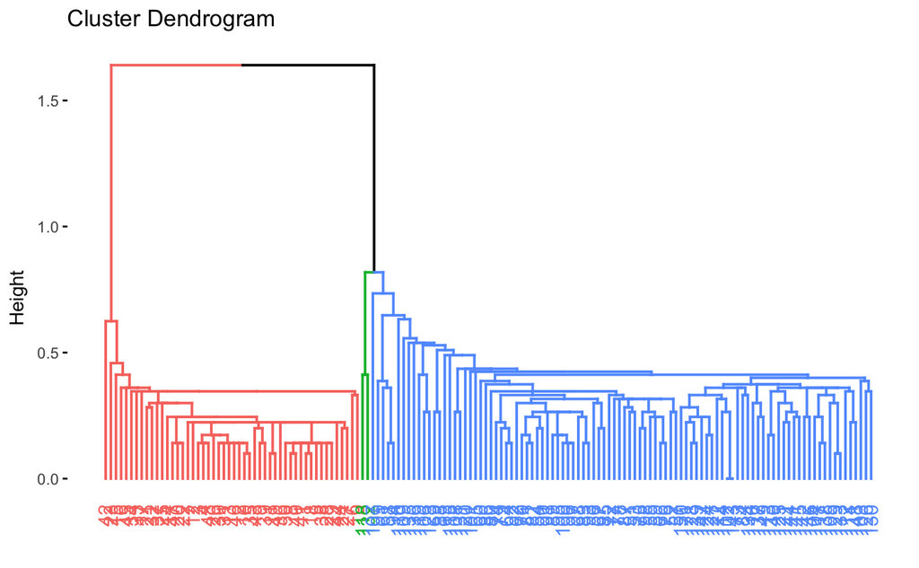

## General considerations on clustering

- as both clustering methods are based on distances in features, we may want to first bring all variables to the same scale
- clusters may be sensitive to details such as scaling or not, whether we take subsets of data or what is the dissimilarity measure in hierarchical clustering. Advice: experiment with the settings and look for consistent patterns.